# Practical Machine Learning Course Project

Nicolas Formoso

20 November 2015

# Introduction

The objective of the course project is to build a predictive model based on the Weight Lifting Exercise Dataset, which contains observations gathered from participants asked to perform various exercises. The “classe” variable in this dataset describes the manner by which participants performed the exercise, and is the target variable for the predictive model.

This write-up will describe the main choices made for this submission: 1. Feature selection 2. Model selection, Cross-validation and model evolution

Before running any of the analysis below, a training subset was created out of the assignment training data, using the caret library’s createDataPartition function, with a 70/30 split:

```r
library(caret)
pml <- read.csv(file="pml-training.csv")
inTrain <- createDataPartition(pml$classe, p=0.7, list=FALSE)
training <- pml[inTrain,]
testing <- pml[-inTrain,]
```

# 1. Feature Selection

In order to select the features that would be used as input into the model itself, the first step taken was to look at the raw data to understand “how the data works”, and the relationship between the variables. This involved inspection of a sample of the data in Excel, and analysis conducted in R.

## 1.1 Data inspection

The first 1000 records were extracted from the data and inspected using Excel. The objective of this step is to gain understanding of the dataset, e.g,. what each record represents, what is the relationship between records, and what kind of information is present in each of the fields. Both testing and training data sets were inspected in this manner.

This exercise yielded the following observations:

1. Each line is an observation that records data from various sensors attached to a participant’s body as they perform a given action. At given intervals, indicated by “windows”, certain variables would be aggregated and calculated by the recorded values within the window (e.g, “kurtosis”, “skewness”, “max”,“min”, etc). It was noted as well that these aggregated variables were not present in the testing set.
2. There were a number of variables found at the beginning of the table, which seems to record metadata, rather than data linked to the target movement:
   - Row
   - User name
   - timestamps
   - new_window
   - num_window
3. The remaining variables were tracking different parts of the movement of a given sensor (e.g., “roll”,“pitch”,“yaw”, etc)

## 1.2-A Feature shortlisting: Exclusion of variables

Based on these observations, the following actions and decisions were made with the objective of shortlisting the features:

1. Since the aggregated variables were not present in the testing set, they were excluded from the shortlisted feature list.
2. Similarly, the “metadata” variables likely had very little predictive significance to the target classe variable and were excluded from the feature shortlist

To exclude these variables above, a vector containing the column numbers was created:

```r
exclude_cols <- c(1,2,3,4,5,6,7,12,13,14,15,16,17,18,19,20,21,22,23,24,25,26,27,28,29,30,31,32,33,34,35,36,50,51,52,53,54,55,56,57,58,59,69,70,71,72,73,74,75,76,77,78,79,80,81,82,83,87,88,89,90,91,92,93,94,95,96,97,98,99,100,101,103,104,105,106,107,108,109,110,111,112,125,126,127,128,129,130,131,132,133,134,135,136,137,138,139,141,142,143,144,145,146,147,148,149,150)
```

Based on this, a “trimmed” dataset was created:

```r
train_trim <- training[,-exclude_cols]
```

The resulting dataset had 53 variables, including the target variable:

```r
dim(train_trim)
```

```
## [1] 13737    53
```

## 1.2-B Feature shortlisting: Correlated variables

Since each sensor had a number of variables tracking the same movement, it was likely that a number of these variables would be highly correlated with one another, and indeed this was confirmed upon running a correlation matrix between the variables.

```r
pml_cor <- abs(cor(train_trim[,-53])) #run correlation matrix excluding classe variable
diag(pml_cor) <- 0 #set diagonal to zero
dim(which(pml_cor > 0.8, arr.ind = TRUE))
```

```
## [1] 38  2
```

Below are examples of box plots generated for this exercise:

Example of variable with **“high”** signficance (roll_belt): Clear grouping can be observed from the plots.

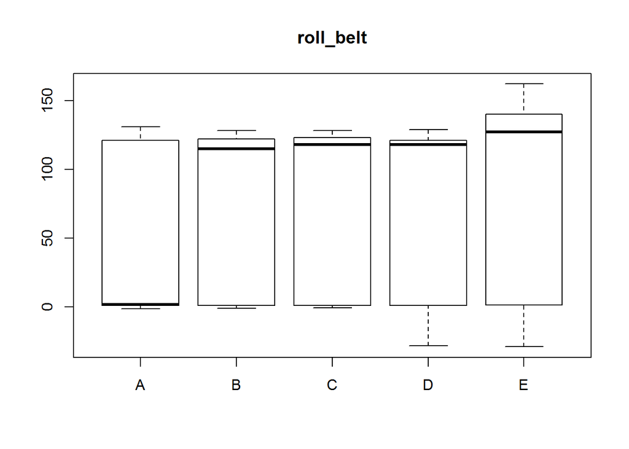

Example of variable with **“medium”** signficance (magnet_arm_y): Less grouping evident, but there is an observable trend.

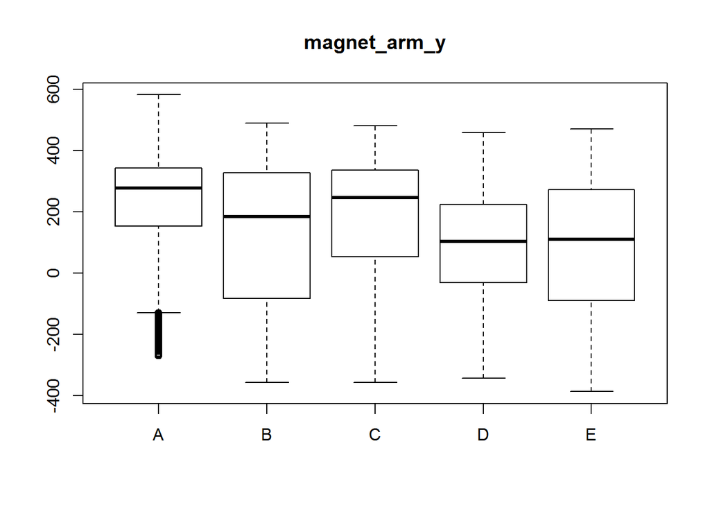

Example of variable with **“low”** signficance (gyros_dumbbell_x): No clear grouping or significant information is provided by the plots.

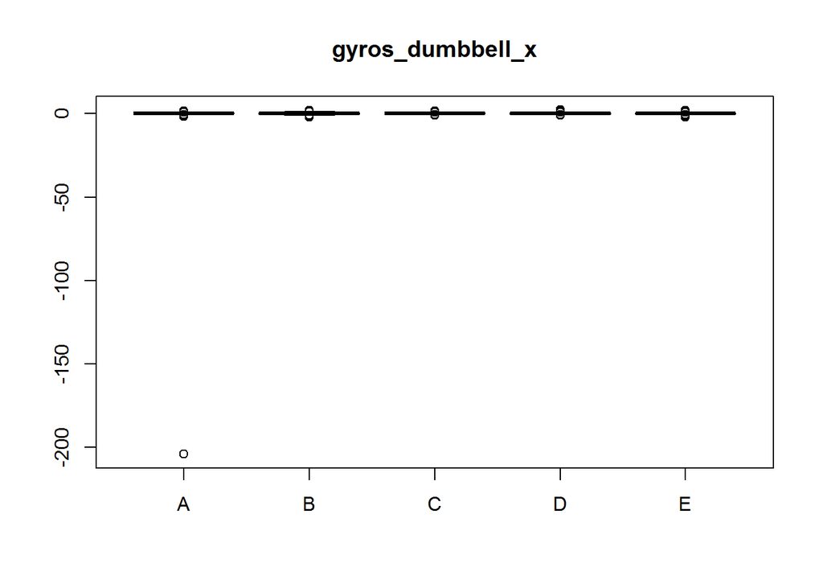

Vectors were thus created for the high- and medium-significance variables:

```r
high_sig_cols <- c(1,3,4,9,10,21,24,38,40,47)
med_sig_cols <- c(5,6,7,8,12,13,14,15,17,18,19,20,22,23,25,26,27,28,29,30,34,35,37,39,41,42,48,50,51,52)
```

At this stage, we have now the following counts of features to be used for predictive modeling:

- 52 total predictive variables, comprised of:
- 10 “high-significance” variables
- 30 “medium-significance” variables
- 12 “low-significance”" variables

# 2. Model selection, cross-validation and model refinement

Given the nature of the problem as one of classification, it was decided that a **Random Forest** model be applied to the training data sets. This decision was also driven by an intuition that was then confirmed when inspecting the data during the feature selection stage: that certain recorded movements signal certain classes more than others.

The strategy from here onward was then to apply random forest modeling to the different variable groups identified, and compare the results of each model accordingly. My initial intuition was that the models using “high” and “high and medium” significance variables would have a smaller error than the model that uses “all shortlisted” variables, due to the noise being introduced by the low-significance variables.

## 2.1 Random Forest applied to “high-significance” variables:

```r
train_trim_high <- train_trim[,high_sig_cols]
modFit_high <- train(classe ~., data=train_trim_high, method="rf",prox=TRUE)
modFit_high
```

**Results: High-significance features**

No pre-processing Resampling: Bootstrapped (25 reps) Summary of sample sizes: 13737, 13737, 13737, 13737, 13737, 13737, … Resampling results across tuning parameters:

| mtry | Accuracy | Kappa | Accuracy SD | Kappa SD |
| --- | --- | --- | --- | --- |
| 2 | 0.9698748 | 0.9618921 | 0.002446088 | 0.003090462 |
| 6 | 0.9690509 | 0.9608596 | 0.002827253 | 0.003562354 |
| 10 | 0.9605265 | 0.9500770 | 0.004282432 | 0.005419146 |

Accuracy was used to select the optimal model using the largest value. The final value used for the model was mtry = 2.

**Confusion Matrix and Statistics**

```r
test_right <- testing$classe
test_pred <- predict(modFit_high, newdata=testing)
confusionMatrix(data=test_pred,reference=test_right)
```

| Prediction | A | B | C | D | E |
| --- | --- | --- | --- | --- | --- |
| A | 1660 | 14 | 5 | 9 | 1 |
| B | 5 | 1097 | 22 | 4 | 3 |
| C | 2 | 25 | 995 | 13 | 3 |
| D | 2 | 3 | 4 | 936 | 4 |
| E | 5 | 0 | 0 | 2 | 1071 |

Overall Statistics

```
           Accuracy : 0.9786
             95% CI : (0.9746, 0.9821)
No Information Rate : 0.2845
P-Value [Acc > NIR] : < 2.2e-16

              Kappa : 0.9729
```

Mcnemar’s Test P-Value : 0.006524

## 2.2 Random Forest applied to both and medium-significance variables:

```r
train_trim_high_med <- train_trim[,c(high_sig_cols,med_sig_cols)]
modFit_highmed <- train(classe ~., data=train_trim_high_med, method="rf",prox=TRUE)
modFit_highmed
```

**Results: High- and Medium-significance features**

No pre-processing Resampling: Bootstrapped (25 reps) Summary of sample sizes: 13737, 13737, 13737, 13737, 13737, 13737, … Resampling results across tuning parameters:

| mtry | Accuracy | Kappa | Accuracy SD | Kappa SD |
| --- | --- | --- | --- | --- |
| 2 | 0.9859049 | 0.9821680 | 0.002142782 | 0.002706979 |
| 21 | 0.9860412 | 0.9823421 | 0.002183208 | 0.002763659 |
| 40 | 0.9776515 | 0.9717272 | 0.004107391 | 0.005199876 |

Accuracy was used to select the optimal model using the largest value. The final value used for the model was mtry = 21.

**Confusion Matrix and Statistics**

```r
test_right <- testing$classe
test_pred_medhigh <- predict(modFit_highmed, newdata=testing)
confusionMatrix(data=test_pred_medhigh,reference=test_right)
```

| Prediction | A | B | C | D | E |
| --- | --- | --- | --- | --- | --- |
| A | 1673 | 13 | 0 | 1 | 0 |
| B | 1 | 1118 | 9 | 1 | 1 |
| C | 0 | 8 | 1016 | 13 | 2 |
| D | 0 | 0 | 1 | 949 | 4 |
| E | 0 | 0 | 0 | 0 | 1075 |

Overall Statistics

```
           Accuracy : 0.9908
             95% CI : (0.988, 0.9931)
No Information Rate : 0.2845
P-Value [Acc > NIR] : < 2.2e-16

              Kappa : 0.9884
```

Mcnemar’s Test P-Value : NA

## 2.3 Random Forest applied to all 52 shortlisted variables:

```r
modFit_all <- train(classe ~., data=train_trim, method="rf",prox=TRUE)
modFit_all
```

**Results: All shortlisted features** Random Forest

No pre-processing Resampling: Bootstrapped (25 reps) Summary of sample sizes: 13737, 13737, 13737, 13737, 13737, 13737, … Resampling results across tuning parameters:

| mtry | Accuracy | Kappa | Accuracy SD | Kappa SD |
| --- | --- | --- | --- | --- |
| 2 | 0.988493 | 0.9854393 | 0.001768106 | 0.002234806 |
| 27 | 0.9886574 | 0.9856486 | 0.001944458 | 0.002457143 |
| 52 | 0.9795619 | 0.9741359 | 0.005186390 | 0.006572463 |

Accuracy was used to select the optimal model using the largest value. The final value used for the model was mtry = 27.

**Confusion Matrix and Statistics**

```r
test_right <- testing$classe
test_pred_all <- predict(modFit_all, newdata=testing)
confusionMatrix(data=test_pred_all,reference=test_right)
```

| Prediction | A | B | C | D | E |
| --- | --- | --- | --- | --- | --- |
| A | 1673 | 12 | 0 | 0 | 0 |
| B | 1 | 1124 | 6 | 0 | 1 |
| C | 0 | 3 | 1019 | 10 | 2 |
| D | 0 | 0 | 1 | 954 | 5 |
| E | 0 | 0 | 0 | 0 | 1074 |

Overall Statistics

```
           Accuracy : 0.993
             95% CI : (0.9906, 0.995)
No Information Rate : 0.2845
P-Value [Acc > NIR] : < 2.2e-16

              Kappa : 0.9912
```

Mcnemar’s Test P-Value : NA

# 3. Conclusions and Final Model

Despite my initial intuition, the model that used all 52 shortlisted variables turned out to have the best result, with an estimated accuracy of 0.993. One explanation is that, while the individual variables might give low significance, the combination of these variables with others might still provide informational value.